# Exam2

Peter Jenkins

3/22/2021

# 1. Import this dataset into R and inspect the first several rows of your data

```r
dat <- read.csv('Exam 2 Data.csv')
head(dat)
```

```
##    y          x1          x2 x3
## 1  2  1.37034210 -0.66615843  b
## 2  2 -0.70417232 -0.03705622  c
## 3  4 -0.04223752 -1.53148692  c
## 4  9 -0.56711072 -0.06529335  b
## 5  1  0.31189773  0.81650472  a
## 6 13 -0.35994479 -0.80042308  b
```

# 2. Fit a Poisson model that assumes your response is a function of x1, x2, and x3. Include an interaction between x1 and x2 only (i.e., do not include an interaction between your categorical variables and any other variables).

```r
fit <- glm(y~ x1* x2 + x3, family =poisson, data=dat)
summary(fit)
```

```
##
## Call:
## glm(formula = y ~ x1 * x2 + x3, family = poisson, data = dat)
##
## Deviance Residuals:
##     Min       1Q   Median       3Q      Max
## -2.3620  -0.6973  -0.1007   0.5236   2.6779
##
## Coefficients:
##             Estimate Std. Error z value Pr(>|z|)
## (Intercept)  1.13258    0.08540  13.262  < 2e-16 ***
## x1          -1.03491    0.05019 -20.620  < 2e-16 ***
## x2          -0.90839    0.06977 -13.021  < 2e-16 ***
## x3b          0.37532    0.09246   4.059 4.92e-05 ***
## x3c         -0.88354    0.12072  -7.319 2.50e-13 ***
## x1:x2       -0.28868    0.05142  -5.614 1.98e-08 ***
## ---
## Signif. codes:  0 '***' 0.001 '**' 0.01 '*' 0.05 '.' 0.1 ' ' 1
##
## (Dispersion parameter for poisson family taken to be 1)
##
##     Null deviance: 720.551  on 99  degrees of freedom
## Residual deviance:  89.088  on 94  degrees of freedom
## AIC: 392.86
##
## Number of Fisher Scoring iterations: 5
```

# 3. Interpret the effect of variable x1 when x2 = -1

```r
b <- coef(fit)
b
```

```
## (Intercept)          x1          x2         x3b         x3c       x1:x2
##   1.1325781  -1.0349058  -0.9083868   0.3753215  -0.8835413  -0.2886813
```

```r
b[2] + b[6] * -1
```

```
##         x1
## -0.7462245
```

# 4. Plot expected counts ±90% confidence intervals over the observed range of variable x1. Assume variable when x2 = -1 and category “a”.

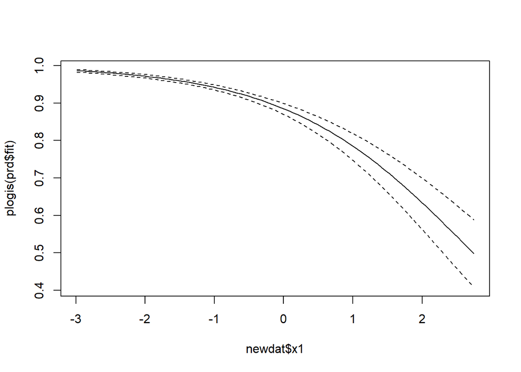

```r
newdat <- data.frame(
  x1 = seq(min(dat$x1), max(dat$x1), length.out = 100),
  x2 = -1,
  x3 = factor('a', levels = c('a', 'b', 'c'))
)

prd <- predict.glm(fit, newdat, se.fit = T)

low <- plogis(prd$fit - qnorm(0.95) * prd$se.fit)
high <- plogis(prd$fit + qnorm(0.95) * prd$se.fit)

plot(x = newdat$x1, y = plogis(prd$fit), ylim = c(min(low), max(high)), type = 'l')
lines(x = newdat$x1, y = low, lty = 2)
lines(x = newdat$x1, y = high, lty = 2)
```

# 5. Interpret the effect of variable x3

```r
summary(fit)
```

```
##
## Call:
## glm(formula = y ~ x1 * x2 + x3, family = poisson, data = dat)
##
## Deviance Residuals:
##     Min       1Q   Median       3Q      Max
## -2.3620  -0.6973  -0.1007   0.5236   2.6779
##
## Coefficients:
##             Estimate Std. Error z value Pr(>|z|)
## (Intercept)  1.13258    0.08540  13.262  < 2e-16 ***
## x1          -1.03491    0.05019 -20.620  < 2e-16 ***
## x2          -0.90839    0.06977 -13.021  < 2e-16 ***
## x3b          0.37532    0.09246   4.059 4.92e-05 ***
## x3c         -0.88354    0.12072  -7.319 2.50e-13 ***
## x1:x2       -0.28868    0.05142  -5.614 1.98e-08 ***
## ---
## Signif. codes:  0 '***' 0.001 '**' 0.01 '*' 0.05 '.' 0.1 ' ' 1
##
## (Dispersion parameter for poisson family taken to be 1)
##
##     Null deviance: 720.551  on 99  degrees of freedom
## Residual deviance:  89.088  on 94  degrees of freedom
## AIC: 392.86
##
## Number of Fisher Scoring iterations: 5
```

# 6. Use contrasts to evaluate the null hypothesis that the difference in log expected count between levels “b” and “c” = 0. Fix x1 and x2 at their means.

```r
b
```

```
## (Intercept)          x1          x2         x3b         x3c       x1:x2
##   1.1325781  -1.0349058  -0.9083868   0.3753215  -0.8835413  -0.2886813
```

```r
x <- matrix(c(0, 0, 0, -1, 1,0), nrow = 1)# nothing for int,  x1,  x2, -1  subtract b from c
x
```

```
##      [,1] [,2] [,3] [,4] [,5] [,6]
## [1,]    0    0    0   -1    1    0
```

```r
y <- matrix(b, ncol = 1)
# matrix math
x %*% y
```

```
##           [,1]
## [1,] -1.258863
```

```r
b[5]- b[4]
```

```
##       x3c
## -1.258863
```

```r
library(multcomp)
summary(glht(fit,x))
```

```
##
##   Simultaneous Tests for General Linear Hypotheses
##
## Fit: glm(formula = y ~ x1 * x2 + x3, family = poisson, data = dat)
##
## Linear Hypotheses:
##        Estimate Std. Error z value Pr(>|z|)
## 1 == 0  -1.2589     0.1197  -10.52   <2e-16 ***
## ---
## Signif. codes:  0 '***' 0.001 '**' 0.01 '*' 0.05 '.' 0.1 ' ' 1
## (Adjusted p values reported -- single-step method)
```

The null hypothesis is that when x1 and x2 are at their means the difference between ‘b’ and ‘c’ is equal to zero. Based on our low pvalue (2e-16) we reject our null hypothesis and can say there is a difference between ‘b’ and ‘c’.

# 7. Derive the test statistic and p-value associated with the interaction between x1 and x2. What is the null hypothesis? Do we reject or fail to reject this null hypothesis? Defend your answer.

```r
s <- summary(fit)[['coefficients']][, 2]

# test statistic
b[6] / s[6]
```

```
##     x1:x2
## -5.614074
```

```r
pnorm(-1 * abs(b[6] / s[6])) * 2
```

```
##        x1:x2
## 1.976182e-08
```

The null hypothesis is that β5=0. To see the interpretation, we can further evaluate our effective slope coefficient for x1. Recall from previously:

yx1+1,x2−yx1,x2=β1+β5x2

which is evaluated at an arbitrary value of x2.

If we evaluate the same expression at x2+1 and find the difference with the previous expression:

yx1+1,x2+1−yx1,x2+1=β1+β5(x2+1)=β1+β5x2+β5 (yx1+1,x2+1−yx1,x2+1)−(yx1+1,x2−yx1,x2)=β5

In words, we can interpret this to mean β5 is the change in the effective slope coefficient of x1 associated with a 1-unit change in x2. Given our small pvalue we can reject the null hypothesis, we can say there is evidence the the effect of variable x1 depends on the level of x2.

# 8. assume you have the following realizations of random variable Y :

y = (1, 0) Further assume realizations of the random variable Y are Bernoulli distributed: y ∼ Bernoulli(p). # What is the probability of observing each of these random variables assuming the log odds of success =-2?

```r
dpois(c(1,0), exp(-2))
```

```
## [1] 0.118205 0.873423
```

# 9. What is the “support” of a Bernoulli random variable? What are the acceptable values of it’s sole parameter? To which quantity do we apply a link function, and why do we do this? What is the principle link function we use in binomial (i.e., logistic) regression, and what it it’s inverse function?

We apply a logit link function to the sole parameter in the Bernoulli distribution that describes the probability of success. We do this so we can model probability of success on the real number line (without constraints), and transform the logit link predictor to a number between 0 and 1 that describes probaility of successs.

We use the logit link function to map a number bounded between 0 and 1 to the real number line.

We use the inverse logit link function (the inverse of the log function) to map a number on the real number line to a positive real number to the (0,1) interval.

# 10. What is a fundamental assumption we make to derive inference when comparing two levels of a categorical random variable?

That linear combinations of Gaussain random variables are themselves random variables.